# Data Science Capstone - Week 2 Report

Subhrajyoty Roy

16 October 2018

# Introduction

This is the report for Week 2 of the Data Science Capstone Project. This capstone project focuses on building a text based prediction algorithm using different statistical and machine learning tools. The goal of this report is to download the data, and visualize the data in order to perform some exploratory analysis, which will give us a better insight of the corpus.

# Loading Required Packages

```r
library(utils)
library(stringi)
library(ngram)
```

# Downloading the Corpus

The corpus is available in the following url: https://d396qusza40orc.cloudfront.net/dsscapstone/dataset/Coursera-SwiftKey.zip We use R to download and unzip the corpus text files for us.

```r
url <- 'https://d396qusza40orc.cloudfront.net/dsscapstone/dataset/Coursera-SwiftKey.zip'
if (!file.exists('Coursera-SwiftKey.zip')){
  # if the file does not exist, then we download it
  download.file(url, destfile = "Coursera-SwiftKey.zip", method = "curl")
}

unzip('Coursera-SwiftKey.zip', exdir = ".")
```

The three datasets are extracted into *final/en-US/* folder within the current working directory.

# Basic Summaries in Corpus

Now that we have our corpus downloaded and extracted, we should check some basic summaries like sizes of the corpus text files, number of sentences etc.

```r
CorpusNames <- c('en_US.blogs', 'en_US.news', 'en_US.twitter')
sizes <- numeric(3)
sizes[1] <- file.info('final/en_US/en_US.blogs.txt')$size/(2^20) #so that it shows in mb
sizes[2] <- file.info('final/en_US/en_US.news.txt')$size/(2^20)
sizes[3] <- file.info('final/en_US/en_US.twitter.txt')$size/(2^20)

# Read blogs data
con <- file('./final/en_US/en_US.blogs.txt')
blogdata <- readLines(con); close(con)

# Read news data
con <- file('./final/en_US/en_US.news.txt')
newsdata <- readLines(con); close(con)

# Read twitter data
con <- file('./final/en_US/en_US.twitter.txt');
twitterdata <- readLines(con); close(con)

lengths <- sapply(list(blogdata, newsdata, twitterdata), length)
Chars <- sapply(list(blogdata, newsdata, twitterdata), function(x){sum(nchar(x))})
Sentences <- sapply(list(blogdata, newsdata, twitterdata), function(x){sum(stri_count_boundaries(x,type = "sentence"))})
Words <- sapply(list(blogdata, newsdata, twitterdata), function(x){sum(stri_count_words(x))})

knitr::kable(data.frame(Corpus = CorpusNames, SizeinMB = sizes, Length = lengths, NumberofSenteces = Sentences, NumberofWords = Words, NumberofCharacters = Chars))
```

| Corpus | SizeinMB | Length | NumberofSenteces | NumberofWords | NumberofCharacters |
| --- | --- | --- | --- | --- | --- |
| en_US.blogs | 200.4242 | 899288 | 2380481 | 37546246 | 206824505 |
| en_US.news | 196.2775 | 1010242 | 2025776 | 34762395 | 203223159 |
| en_US.twitter | 159.3641 | 2360148 | 3780372 | 30093369 | 162096031 |

# Sampling the Dataset

Since, the corpus is large in size, so we select 5% texts from each of the three files, and merge them together to form a corpus of reasonable size, using which we can perform related analysis and development of the text prediction system.

```r
set.seed(19102018)  #set a seed for reproducbility
blogsamples <- blogdata[sample(length(blogdata), size = (0.05*length(blogdata)), replace = FALSE)]  #sample the blog data
newssamples <- newsdata[sample(length(newsdata), size = (0.05*length(newsdata)), replace = FALSE)]  #sample the news data
twittersamples <- twitterdata[sample(length(twitterdata), size = (0.05*length(twitterdata)), replace = FALSE)]  #sample the twitter data

rm(blogdata)
rm(newsdata)
rm(twitterdata)  #remove the original data as they would not be required again
```

Now that we have sampled our texts, we need to merge these three samples together to form our corpus.

```r
corpus <- c(blogsamples, newssamples, twittersamples) #make the corpus

#now individual samples can be removed
rm(blogsamples)
rm(newssamples)
rm(twittersamples)
```

# Cleaning the Corpus

To clean the text, we shall first make every text to lowercase letters so that no ambiguity arises in case of other transformations. We should be concerned with the following steps in order to clean the data.

1. Remove optional spaces between different words.
2. Perform a profanity filtering. For this, we shall use the words banned by Google for profanity filtering. The list of words are [here](https://raw.githubusercontent.com/RobertJGabriel/Google-profanity-words/master/list.txt)
3. Remove any URL occuring in the text.
4. Remove any appearance of abbreviations.
5. Remove any appearance of punctuation marks.
6. Remove any repeated words.
7. Remove any appearance of digits.
8. Remove any NonASCII character.

```r
url <- 'https://raw.githubusercontent.com/RobertJGabriel/Google-profanity-words/master/list.txt'  #download the profanity corpus
if (!file.exists('bad-words.txt')){
  # if the file does not exist, then we download it
  download.file(url, destfile = "bad-words.txt", method = "curl")
}
con <- file('./bad-words.txt')
badwords <- readLines(con); close(con)

corpus <- iconv(corpus, "latin1", "ASCII", sub="")  #remove nonASCII characters
corpus <- gsub("\\s+"," ",corpus) ## Removing optional space
corpus <- tolower(corpus)  ## lowercasing the letters
for (badword in badwords){
  corpus <- gsub(paste0("\\s",badword,"\\s"), "", corpus)
  message(badword)  #just for checking
} #remove all bad words that appears
corpus <- gsub("http[[:alnum:]]*","",corpus) #remove any URL
corpus <- gsub("([a-z]\\.){2,}","", corpus) #remove any abbreviations
corpus <- gsub("[[:digit:]]","", corpus)  #remove any digits
corpus <- gsub("(\\w+\\s)\\1+","\\1", corpus)  #remove the repeated word
corpus <- gsub("[[:punct:]]", "", corpus) #remove any punctuation marks
```

Now that our corpus is cleaned, we save it in a text file for future references.

```r
con <- file('./cleaned-corpus.txt')
writeLines(corpus, con); close(con)
```

# Building ist of frequent N-Grams in the Corpus

We compute the list of the most frequent N-Grams in the corpus. This will serve as a basis for the text based prediction model. For this purpose, we are using *ngram* library which performs fast n-gram tokenization. We present the top 10 frequent n-grams for n=1,2,3,4 and 5 and visualize the corresponding bar diagram.

Now, there might be some sentences remaining which has less than 3 words. These sentences clearly would not provide a good corpus for text prediction using n-grams.

```r
nwords <- stri_count_words(corpus)  #count the number of words
print(sum(nwords < 3)/length(nwords))
```

```
[1] 0.0367336
```

We see that this makes us to remove about 3% of the corpus.

```r
corpus <- corpus[nwords>=3]  #keep those corpus texts where there are at least 3 words.
```

## 1-Gram or Words

```r
ng <- ngram(corpus, n=1)  #get the one_grams
ng_table <- head(get.phrasetable(ng), 10) #get top 10 entries
knitr::kable(ng_table)
```

| ngrams | freq | prop |
| --- | --- | --- |
| the | 237130 | 0.0479693 |
| to | 137470 | 0.0278089 |
| and | 119021 | 0.0240769 |
| a | 117949 | 0.0238600 |
| of | 99627 | 0.0201536 |
| in | 81300 | 0.0164463 |
| i | 81005 | 0.0163866 |
| for | 54938 | 0.0111135 |
| that | 51487 | 0.0104154 |
| is | 50042 | 0.0101230 |

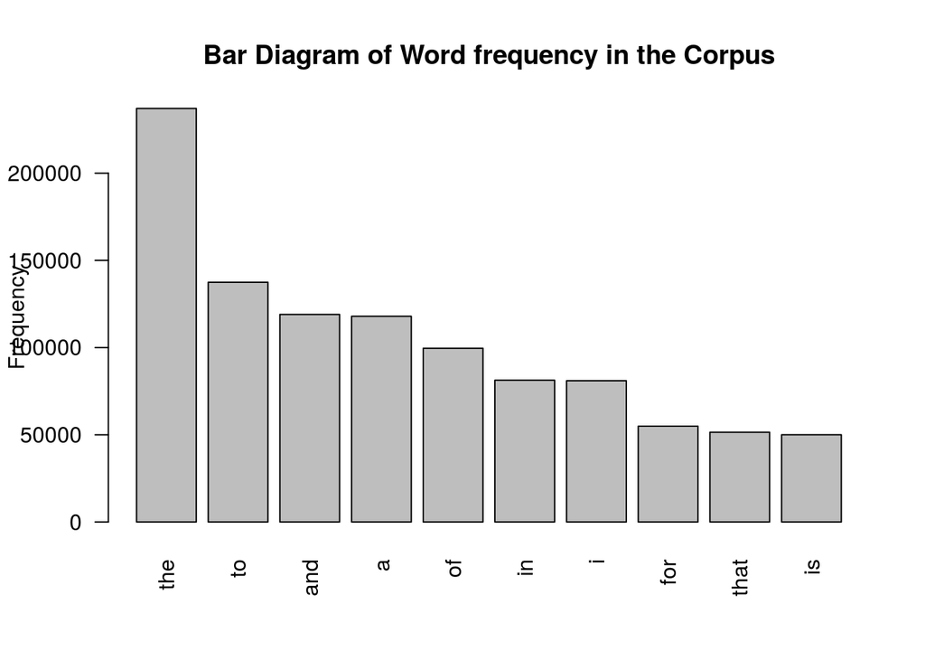

```r
barplot(ng_table$freq, names.arg = ng_table$ngrams, las = 2, ylab = "Frequency", main = "Bar Diagram of Word frequency in the Corpus")
```

## 2-Gram or Bigrams

```r
ng <- ngram(corpus, n=2)  #get the bi_grams
ng_table <- head(get.phrasetable(ng), 10) #get top 10 entries
knitr::kable(ng_table)
```

| ngrams | freq | prop |
| --- | --- | --- |
| of the | 21491 | 0.0045361 |
| in the | 20178 | 0.0042590 |
| to the | 10850 | 0.0022901 |
| for the | 10064 | 0.0021242 |
| on the | 9637 | 0.0020341 |
| to be | 8296 | 0.0017510 |
| at the | 7053 | 0.0014887 |
| and the | 6178 | 0.0013040 |
| in a | 5992 | 0.0012647 |
| with the | 5228 | 0.0011035 |

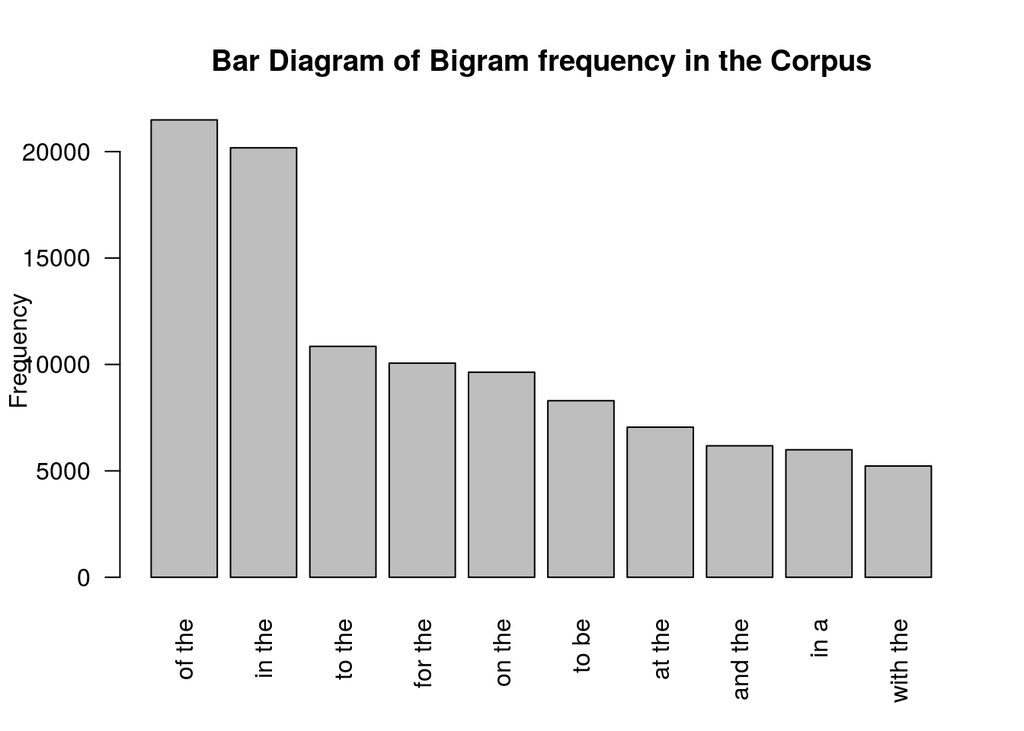

```r
barplot(ng_table$freq, names.arg = ng_table$ngrams, las = 2, ylab = "Frequency", main = "Bar Diagram of Bigram frequency in the Corpus")
```

## 3-Gram or Trigrams

```r
ng <- ngram(corpus, n=3)  #get the tri_grams
ng_table <- head(get.phrasetable(ng), 10) #get top 10 entries
knitr::kable(ng_table)
```

| ngrams | freq | prop |
| --- | --- | --- |
| one of the | 1651 | 0.0003643 |
| a lot of | 1426 | 0.0003146 |
| thanks for the | 1177 | 0.0002597 |
| to be a | 925 | 0.0002041 |
| going to be | 906 | 0.0001999 |
| the end of | 770 | 0.0001699 |
| out of the | 723 | 0.0001595 |
| i want to | 721 | 0.0001591 |
| it was a | 693 | 0.0001529 |
| some of the | 689 | 0.0001520 |

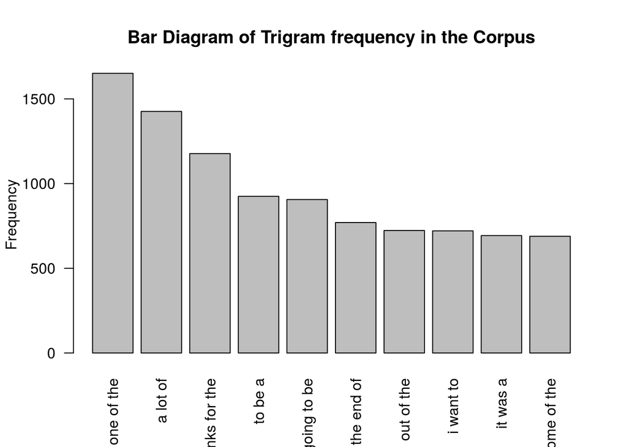

```r
barplot(ng_table$freq, names.arg = ng_table$ngrams, las = 2, ylab = "Frequency", main = "Bar Diagram of Trigram frequency in the Corpus")
```

## 4-gram or Tetragrams

```r
nwords <- stri_count_words(corpus)
ng <- ngram(corpus[nwords>=4], n=4)  #get the tri_grams
ng_table <- head(get.phrasetable(ng), 10) #get top 10 entries
knitr::kable(ng_table)
```

| ngrams | freq | prop |
| --- | --- | --- |
| the end of the | 409 | 9.45e-05 |
| the rest of the | 335 | 7.74e-05 |
| at the end of | 327 | 7.56e-05 |
| thanks for the follow | 300 | 6.94e-05 |
| for the first time | 272 | 6.29e-05 |
| at the same time | 256 | 5.92e-05 |
| when it comes to | 228 | 5.27e-05 |
| one of the most | 201 | 4.65e-05 |
| to be able to | 200 | 4.62e-05 |
| is going to be | 199 | 4.60e-05 |

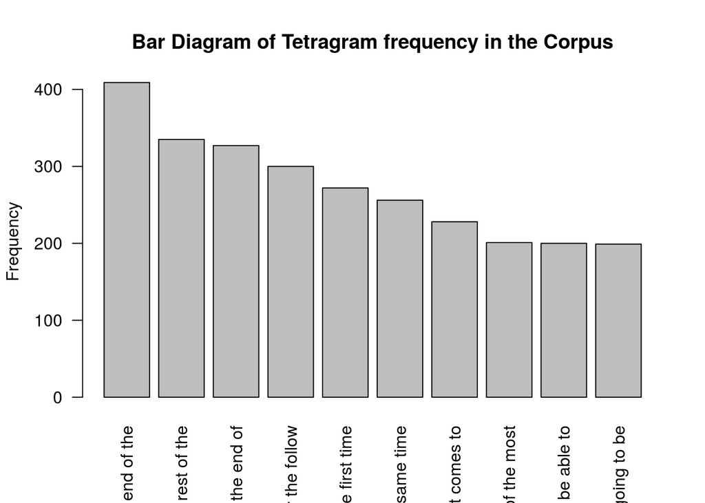

```r
barplot(ng_table$freq, names.arg = ng_table$ngrams, las = 2, ylab = "Frequency", main = "Bar Diagram of Tetragram frequency in the Corpus")
```

## 5-gram or Pentagrams

```r
ng <- ngram(corpus[nwords>=5], n=5)  #get the tri_grams
ng_table <- head(get.phrasetable(ng), 10) #get top 10 entries
knitr::kable(ng_table)
```

| ngrams | freq | prop |
| --- | --- | --- |
| at the end of the | 190 | 4.60e-05 |
| for the first time in | 82 | 1.99e-05 |
| in the middle of the | 80 | 1.94e-05 |
| the end of the day | 78 | 1.89e-05 |
| by the end of the | 63 | 1.53e-05 |
| thank you so much for | 63 | 1.53e-05 |
| for the rest of the | 59 | 1.43e-05 |
| its going to be a | 59 | 1.43e-05 |
| there are a lot of | 53 | 1.28e-05 |
| happy mothers day to all | 52 | 1.26e-05 |

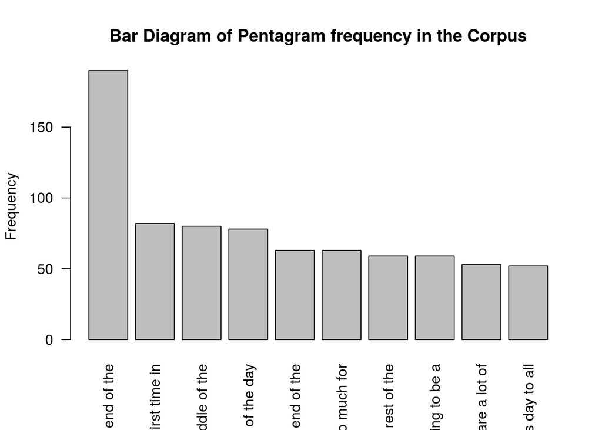

```r
barplot(ng_table$freq, names.arg = ng_table$ngrams, las = 2, ylab = "Frequency", main = "Bar Diagram of Pentagram frequency in the Corpus")
```

# Goals for Text Prediction Application

1. Using a basic 5-gram model to predict the next word based on the previous three words. Including 2-gram, 3-gram and 4-gram models at the initial level.
2. Create larger corpus sizes in order to assess better accuracy.
3. Include prediction of punctuation marks along with the word.
4. Store the n-gram objects efficiently to be used on light-weight devices.
5. Optimize the running time of the prediction algorithm and locate the bottlenecks of the code for efficiency in speed.